# Analysis of Flight Delays

## Preliminary Wrangling

> The data for this analysis was obtained from the [Bureau of Transportation Staticis](https://www.transtats.bts.gov/DL_SelectFields.asp?Table_ID=236). All domestic United States regions for years 2018 and 2019 were download by month and concatenated together outside of this notebook into two separate files for each year. It is a rather large set of data so I've separated the cleaning in order to speed processing of later cells.

```python
# import all packages and set plots to be embedded inline
import numpy as np
import pandas as pd
import matplotlib.pyplot as plt
import seaborn as sb
from scipy import stats

%matplotlib inline
```

```python
# create a dictionary of carriers for plot labels
carriers = {'9E':'Pinnacle Airlines Inc.',
            'AA':'American Airlines Inc.',
            'AS':'Alaska Airlines Inc.',
            'B6':'JetBlue Airways',
            'DL':'Delta Air Lines Inc.',
            'EV':'Atlantic Southeast Airlines',
            'F9':'Frontier Airlines Inc.',
            'G4':'Allegiant Air',
            'HA':'Hawaiian Airlines Inc.',
            'MQ':'American Eagle Airlines Inc.',
            'NK':'Spirit Air Lines',
            'OH':'Comair Inc.',
            'OO':'Skywest Airlines Inc.',
            'UA':'United Air Lines Inc.',
            'VX':'Virgin America',
            'WN':'Southwest Airlines Co.',
            'YV':'Mesa Airlines Inc.',
            'YX':'Midwest Airline, Inc.'}
```

# Gather

Load the cleaned data file created by the separated wrangling notebook.

```python
delayed_flights = pd.read_csv('delayed_flights.csv')
```

# Assess

Examine the cleanliness and tidiness of the data

```python
delayed_flights.head()
```

|  | YEAR | MONTH | DAY_OF_MONTH | DAY_OF_WEEK | OP_UNIQUE_CARRIER | ORIGIN | DEST | FLIGHTS | DEP_DELAY_MEAN | DEP_DELAY_MIN | DEP_DELAY_MAX | ARR_DELAY_MEAN | ARR_DELAY_MIN | ARR_DELAY_MAX | MEAN_DISTANCE |
| --- | --- | --- | --- | --- | --- | --- | --- | --- | --- | --- | --- | --- | --- | --- | --- |
| 0 | 2018 | 1 | 1 | 1 | 9E | AGS | ATL | 1 | 32.0 | 32.0 | 32.0 | 30.0 | 30.0 | 30.0 | 143.0 |
| 1 | 2018 | 1 | 1 | 1 | 9E | ATL | AEX | 1 | 55.0 | 55.0 | 55.0 | 43.0 | 43.0 | 43.0 | 500.0 |
| 2 | 2018 | 1 | 1 | 1 | 9E | ATL | BMI | 1 | 0.0 | 0.0 | 0.0 | 53.0 | 53.0 | 53.0 | 533.0 |
| 3 | 2018 | 1 | 1 | 1 | 9E | ATL | CHS | 1 | 80.0 | 80.0 | 80.0 | 72.0 | 72.0 | 72.0 | 259.0 |
| 4 | 2018 | 1 | 1 | 1 | 9E | ATL | CSG | 1 | 102.0 | 102.0 | 102.0 | 139.0 | 139.0 | 139.0 | 83.0 |

```python
delayed_flights.info()
```

```
<class 'pandas.core.frame.DataFrame'>
RangeIndex: 1060606 entries, 0 to 1060605
Data columns (total 15 columns):
YEAR                 1060606 non-null int64
MONTH                1060606 non-null int64
DAY_OF_MONTH         1060606 non-null int64
DAY_OF_WEEK          1060606 non-null int64
OP_UNIQUE_CARRIER    1060606 non-null object
ORIGIN               1060606 non-null object
DEST                 1060606 non-null object
FLIGHTS              1060606 non-null int64
DEP_DELAY_MEAN       1060606 non-null float64
DEP_DELAY_MIN        1060606 non-null float64
DEP_DELAY_MAX        1060606 non-null float64
ARR_DELAY_MEAN       1060606 non-null float64
ARR_DELAY_MIN        1060606 non-null float64
ARR_DELAY_MAX        1060606 non-null float64
MEAN_DISTANCE        1060606 non-null float64
dtypes: float64(7), int64(5), object(3)
memory usage: 121.4+ MB
```

```python
print(delayed_flights['DEP_DELAY_MEAN'].min())
print(delayed_flights['DEP_DELAY_MEAN'].max())
```

```
0.0
1439.0
```

```python
print(delayed_flights['ARR_DELAY_MEAN'].min())
print(delayed_flights['ARR_DELAY_MEAN'].max())
```

```
15.0
1540.0
```

```python
delayed_flights['OP_UNIQUE_CARRIER'].value_counts()
```

```
WN    140971
AA    137904
OO    116933
DL    114009
UA     96984
B6     54241
YX     50946
MQ     48119
NK     45536
AS     43555
YV     41586
OH     38502
EV     35922
9E     35598
F9     30697
G4     18081
HA      9251
VX      1771
Name: OP_UNIQUE_CARRIER, dtype: int64
```

```python
delayed_flights.describe()
```

|  | YEAR | MONTH | DAY_OF_MONTH | DAY_OF_WEEK | FLIGHTS | DEP_DELAY_MEAN | DEP_DELAY_MIN | DEP_DELAY_MAX | ARR_DELAY_MEAN | ARR_DELAY_MIN | ARR_DELAY_MAX | MEAN_DISTANCE |
| --- | --- | --- | --- | --- | --- | --- | --- | --- | --- | --- | --- | --- |
| count | 1.060606e+06 | 1.060606e+06 | 1.060606e+06 | 1.060606e+06 | 1.060606e+06 | 1.060606e+06 | 1.060606e+06 | 1.060606e+06 | 1.060606e+06 | 1.060606e+06 | 1.060606e+06 | 1.060606e+06 |
| mean | 2.018507e+03 | 6.526761e+00 | 1.566455e+01 | 3.944081e+00 | 1.246305e+00 | 5.066833e+01 | 4.552961e+01 | 5.651095e+01 | 5.976163e+01 | 5.491358e+01 | 6.527242e+01 | 8.853535e+02 |
| std | 4.999473e-01 | 3.358407e+00 | 8.717362e+00 | 1.991248e+00 | 6.543648e-01 | 9.026142e+01 | 8.836122e+01 | 9.917483e+01 | 8.654826e+01 | 8.439300e+01 | 9.556346e+01 | 6.440166e+02 |
| min | 2.018000e+03 | 1.000000e+00 | 1.000000e+00 | 1.000000e+00 | 1.000000e+00 | 0.000000e+00 | 0.000000e+00 | 0.000000e+00 | 1.500000e+01 | 1.500000e+01 | 1.500000e+01 | 3.100000e+01 |
| 25% | 2.018000e+03 | 4.000000e+00 | 8.000000e+00 | 2.000000e+00 | 1.000000e+00 | 3.000000e+00 | 0.000000e+00 | 3.000000e+00 | 2.200000e+01 | 2.000000e+01 | 2.200000e+01 | 4.080000e+02 |
| 50% | 2.019000e+03 | 7.000000e+00 | 1.600000e+01 | 4.000000e+00 | 1.000000e+00 | 2.700000e+01 | 2.200000e+01 | 3.000000e+01 | 3.400000e+01 | 3.000000e+01 | 3.600000e+01 | 7.230000e+02 |
| 75% | 2.019000e+03 | 9.000000e+00 | 2.300000e+01 | 6.000000e+00 | 1.000000e+00 | 6.000000e+01 | 5.300000e+01 | 6.700000e+01 | 6.300000e+01 | 5.600000e+01 | 7.000000e+01 | 1.121000e+03 |
| max | 2.019000e+03 | 1.200000e+01 | 3.100000e+01 | 7.000000e+00 | 1.400000e+01 | 1.439000e+03 | 1.439000e+03 | 1.439000e+03 | 1.540000e+03 | 1.540000e+03 | 1.540000e+03 | 5.095000e+03 |

# Data Assessment

The data is fairly clean and tidy but there are a few things that need to be addressed:

1. Columns YEAR, MONTH, DAY_OF_MONTH and DAY_OF_WEEK are numeric columns

# Clean

```python
# Convert YEAR, MONTH, DAY_OF_MONTH and DAY_OF_WEEK into ordered categorical types for easier plotting
ordinal_var_dict = {'YEAR': [2018,2019],
                    'MONTH': [1,2,3,4,5,6,7,8,9,10,11,12],
                    'DAY_OF_MONTH': [1,2,3,4,5,6,7,8,9,10,11,12,13,14,15,16,17,18,19,20,21,22,23,24,25,26,27,28,29,30,31],
                    'DAY_OF_WEEK': [1,2,3,4,5,6,7]}

for var in ordinal_var_dict:
    ordered_var = pd.api.types.CategoricalDtype(ordered = True,
                                                categories = ordinal_var_dict[var])
    delayed_flights[var] = delayed_flights[var].astype(ordered_var)
```

```python
delayed_flights.info()
```

```
<class 'pandas.core.frame.DataFrame'>
RangeIndex: 1060606 entries, 0 to 1060605
Data columns (total 15 columns):
YEAR                 1060606 non-null category
MONTH                1060606 non-null category
DAY_OF_MONTH         1060606 non-null category
DAY_OF_WEEK          1060606 non-null category
OP_UNIQUE_CARRIER    1060606 non-null object
ORIGIN               1060606 non-null object
DEST                 1060606 non-null object
FLIGHTS              1060606 non-null int64
DEP_DELAY_MEAN       1060606 non-null float64
DEP_DELAY_MIN        1060606 non-null float64
DEP_DELAY_MAX        1060606 non-null float64
ARR_DELAY_MEAN       1060606 non-null float64
ARR_DELAY_MIN        1060606 non-null float64
ARR_DELAY_MAX        1060606 non-null float64
MEAN_DISTANCE        1060606 non-null float64
dtypes: category(4), float64(7), int64(1), object(3)
memory usage: 93.1+ MB
```

```python
delayed_flights.shape
```

```
(1060606, 15)
```

### What is/are the main feature(s) of interest in your dataset?

> I'm intrested in determining if there are certain characteristics such as day of the week, month, origin, or destination that correlate with delays.

### What features in the dataset do you think will help support your investigation into your feature(s) of interest?

> I expect that winter months will have the highest correlation to delays. I suspect that certain busy days of the week might also be a factor.

## Univariate Exploration

> In this section, I will start with a histogram to view the distribution of the main variables of interest: departure and arrival delays.

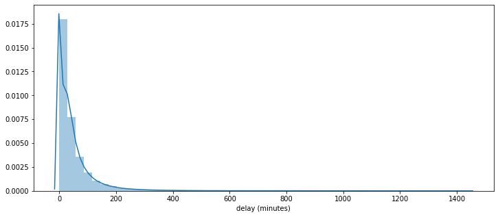

```python
# Let's start with a distribution plot of the departure delays
plt.figure(figsize=[12,5])
sb.distplot(delayed_flights['DEP_DELAY_MEAN']);
plt.xlabel('delay (minutes)');
```

```python
# Generate a common tick scale for the next few plots
delay_ticks = [1,5,15,30,60,120,240,480,960,1920]
log_ticks = np.log(delay_ticks)
```

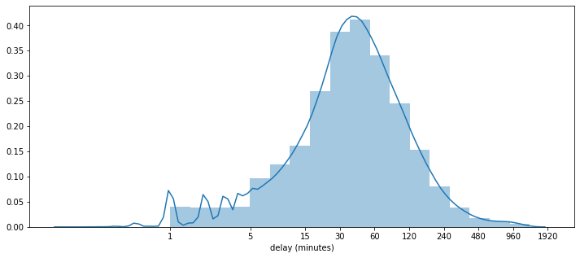

```python
# Normalize the departure delays using log
delayed_departures = delayed_flights[delayed_flights['DEP_DELAY_MEAN'] > 0].copy()
delayed_departures['DEP_DELAY_NORM'] = np.log(delayed_departures['DEP_DELAY_MEAN'])
bins = np.arange(0, delayed_departures['DEP_DELAY_NORM'].max()+.4, .4)
plt.figure(figsize=[12,5])
sb.distplot(delayed_departures['DEP_DELAY_NORM'], bins=bins)
plt.xticks(log_ticks, delay_ticks);
plt.xlabel('delay (minutes)');
```

> That is a much more normal distribution that is unimodal. There does seem to be an unusually high number of delays that were less than 5 minutes. Those would ordinarily go unnoticed by a consumer.

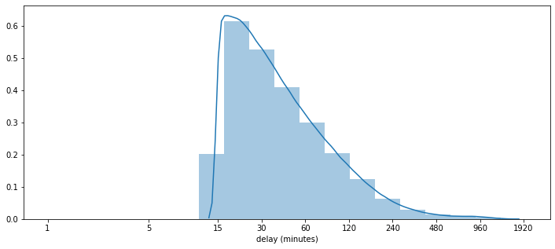

```python
# We already know that we have to normalize the delays
delayed_arrivals = delayed_flights[delayed_flights['ARR_DELAY_MEAN'] > 0].copy()
delayed_arrivals['ARR_DELAY_NORM'] = np.log(delayed_arrivals['ARR_DELAY_MEAN'])
bins = np.arange(0, delayed_arrivals['ARR_DELAY_NORM'].max()+.4, .4)
plt.figure(figsize=[12,5])
sb.distplot(delayed_arrivals['ARR_DELAY_NORM'], bins=bins)
plt.xticks(log_ticks, delay_ticks);
plt.xlabel('delay (minutes)');
```

> Even normalized the arrival delays are not quite normally distributed. There seems to be a sharp increase in arrival delays due to the absence of any delays less than 15 minutes.

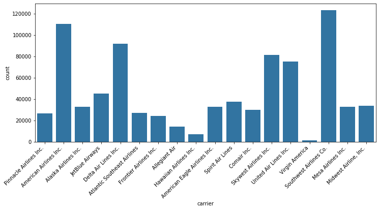

```python
default_color = sb.color_palette()[0]
plt.figure(figsize=[12,5])
plt.xlabel('carrier')
ax = sb.countplot(data=delayed_departures, x='OP_UNIQUE_CARRIER', color=default_color);
ax.set_xticklabels(carriers.values(), rotation=45, horizontalalignment='right');
ax.set_xlabel('carrier')
```

> While the straight count of departure delays by carrier is interesting it isn't statistically relevent because some carriers operate more flights than others.

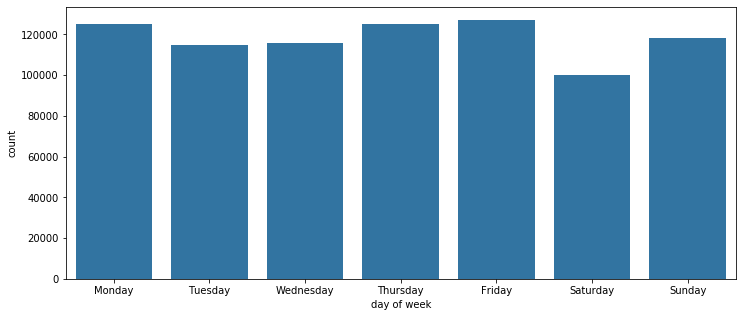

```python
default_color = sb.color_palette()[0]
plt.figure(figsize=[12,5])
sb.countplot(data=delayed_departures, x='DAY_OF_WEEK', color=default_color);
plt.xticks([0,1,2,3,4,5,6],['Monday','Tuesday','Wednesday','Thursday','Friday','Saturday','Sunday']);
plt.xlabel('day of week');
```

> It would seem that Saturday is the best day to fly if you want to have the lowest chance of encountering a delay folowed by Tuesday and Wednesday. The worst days with the most delayed flights are Monday, Thursday and Friday.

### Discuss the distribution(s) of your variable(s) of interest. Were there any unusual points? Did you need to perform any transformations?

> The delays were fairly right skewed and required scaling to produce a normal distribution. I used numpy.log() which produced a reasonably normal distribution for departure delays but did not work quite as well for arrival delays due to there being no arrival delays less than 15 minutes. It is really the arrival delays that matter since those can lead to missed connections among other things.

### Of the features you investigated, were there any unusual distributions? Did you perform any operations on the data to tidy, adjust, or change the form of the data? If so, why did you do this?

> There were a fair amount of short departure delays that were most likely not even noticed by normal consumers. These could probably be omitted to further improve the normal distribution of departure delays. There were also certain carriers that had serveral times more departure delays that likely operate more flights.

## Bivariate Exploration

> In this section, investigate relationships between pairs of variables in your data. Make sure the variables that you cover here have been introduced in some fashion in the previous section (univariate exploration).

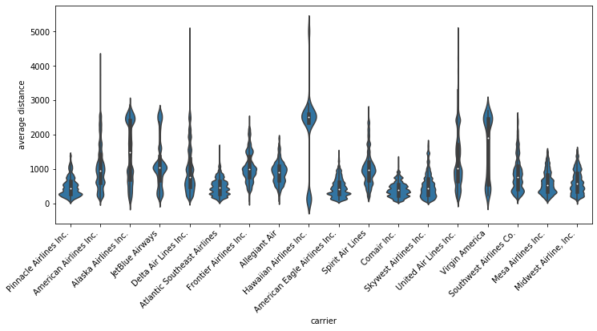

```python
default_color = sb.color_palette()[0]
plt.figure(figsize=[12,5])
ax = sb.violinplot(data=delayed_arrivals, x='OP_UNIQUE_CARRIER', y='MEAN_DISTANCE', color=default_color);
ax.set_xticklabels(carriers.values(), rotation=45, horizontalalignment='right');
ax.set_xlabel('carrier')
ax.set_ylabel('average distance');
```

> Using a violin plot shows that different carrierss operate flights of varying distances. For example, Hawaiin Airlines operates a few very short flights and a lot of longer flights, probably between Hawaii and California. Surprisingly American, United and Delta operate a wide range of flights but mostly short to midrange flights. Distance might be a factor in delays. Let's examine that with the following scatter plot.

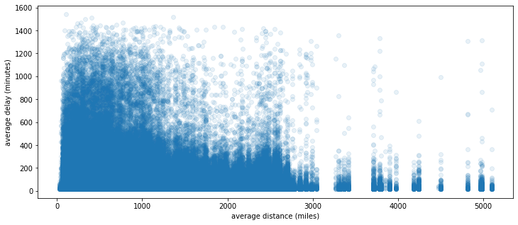

```python
plt.figure(figsize=[12,5])
plt.scatter(data=delayed_arrivals, x='MEAN_DISTANCE', y='ARR_DELAY_MEAN', alpha='.1');
plt.xlabel('average distance (miles)');
plt.ylabel('average delay (minutes)');
```

> From the above scatter plot we can definitely see a negative correlation between the distance of a flight and delay. I had to add transparency to work around the overplotting. At the higher distances there appear to be some gaps. I had expected to see longer flights having worse departure delays but that doesn't seem to be the case. Since longer flights can only be flown a few times in a day I next examine delays by the number of flights.

```python
# Generate a new tick scale for the next few plots since arrival delays start at 15 minutes
delay_ticks = [10,15,30,60,120,240,480,960,1920]
log_ticks = np.log(delay_ticks)
```

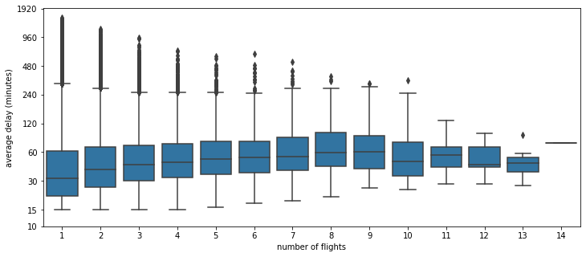

```python
default_color = sb.color_palette()[0]
plt.figure(figsize=[12,5])
sb.boxplot(data=delayed_arrivals, x='FLIGHTS', y='ARR_DELAY_NORM', color=default_color);
plt.xlabel('number of flights');
plt.ylabel('average delay (minutes)');
plt.yticks(log_ticks, delay_ticks);
```

> From the above it does appear that the number of flights made by a carrier between an origin and destination has a little impact on the length of delay, especially when a carrier operates around 8 flights with the fewest flights having the shortest delays. This might just be a snowball effect where earlier flights result in subsequent flights also being delayed though. Since we know that some carriers fly short range and others long range and that more flights operated in a day tend to have longer delays does that mean certain carriers have shorter delays?

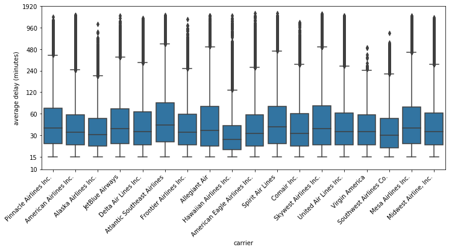

```python
default_color = sb.color_palette()[0]
plt.figure(figsize=[12,5])
ax = sb.boxplot(data=delayed_arrivals, x='OP_UNIQUE_CARRIER', y='ARR_DELAY_NORM', color=default_color);
ax.set_xticklabels(carriers.values(), rotation=45, horizontalalignment='right');
ax.set_xlabel('carrier')
ax.set_ylabel('average delay (minutes)');
plt.yticks(log_ticks, delay_ticks);
```

> All carriers have outliers that show some very long delays but based on the inner quartiles some carriers fare better than others. Next I examine delays by the day of the week as well as month to find out if there are better months and then days.

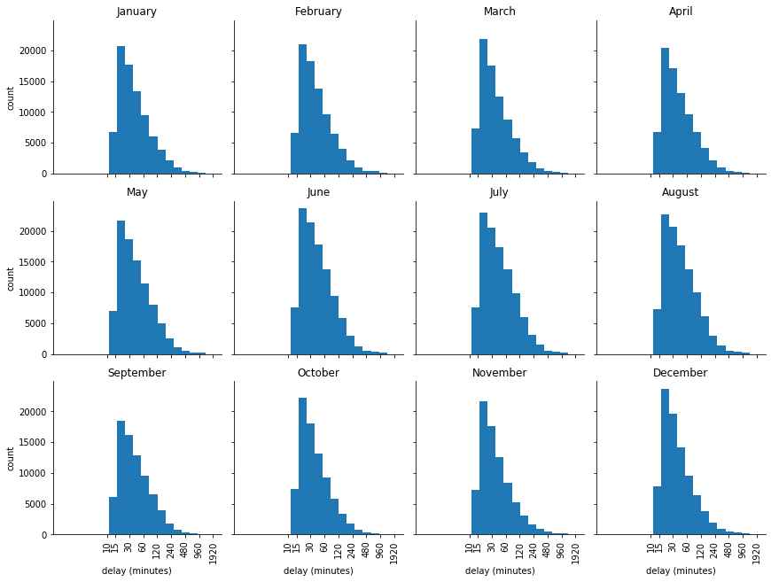

```python
bins = np.arange(0, delayed_arrivals['ARR_DELAY_NORM'].max()+.4, .4)
g = sb.FacetGrid(data=delayed_arrivals, col='MONTH', col_wrap=4);
g.map(plt.hist, 'ARR_DELAY_NORM', bins=bins);
g.set_axis_labels('delay (minutes)', 'count')
g.set(xticks=log_ticks);
g.set_xticklabels(delay_ticks, rotation=90, horizontalalignment='center');
for ax, title in zip(g.axes.flat, ['January','February','March','April','May','June','July','August','September','October','November','December']):
    ax.set_title(title)
```

> It would appear that the summer months actually have the most flights with delays and not the winter months. The best months appear to be April and September.

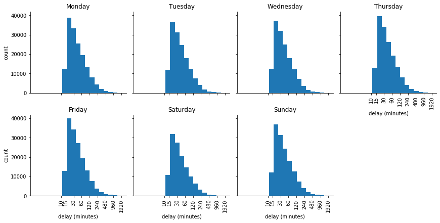

```python
bins = np.arange(0, delayed_arrivals['ARR_DELAY_NORM'].max()+.4, .4)
g = sb.FacetGrid(data=delayed_arrivals, col='DAY_OF_WEEK', col_wrap=4);
g.map(plt.hist, 'ARR_DELAY_NORM', bins=bins);
g.set_axis_labels('delay (minutes)', 'count')
g.set(xticks=log_ticks);
g.set_xticklabels(delay_ticks, rotation=90, horizontalalignment='center');
for ax, title in zip(g.axes.flat, ['Monday','Tuesday','Wednesday','Thursday','Friday','Saturday','Sunday']):
    ax.set_title(title)
```

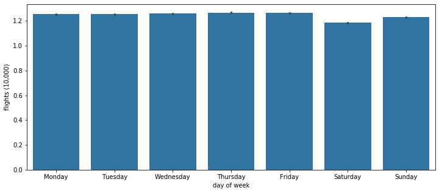

```python
base_color = sb.color_palette()[0]
plt.figure(figsize=[12,5])
sb.barplot(data=delayed_flights, x='DAY_OF_WEEK', y='FLIGHTS', color = base_color)
plt.xticks([0,1,2,3,4,5,6],['Monday','Tuesday','Wednesday','Thursday','Friday','Saturday','Sunday']);
plt.xlabel('day of week');
plt.ylabel('flights (10,000)')
```

### Talk about some of the relationships you observed in this part of the investigation. How did the feature(s) of interest vary with other features in the dataset?

> I found that flight distance had a negative correlation with delays. It was hard to see due to overplotting until a very small transparency value was used. Flights of around 3,000 miles and up seem to show little to no correlation however and have the smallest delays. Even though I considered delays greater than 24 hours to be equivalent to a cancellation there still seem to be a lot of delays that come close to that threshold. Also, certain carriers had less delays than other carriers. It does not appear that winters have much of an impact on delays. Instead it would appear that the most delays occur between May and August during summer vacations.

### Did you observe any interesting relationships between the other features (not the main feature(s) of interest)?

> Major airlines like American, United and Delta operate more short to mid range flights. The number of trips a carrier makes between origin and destination has some correlation to delays. Flights on Saturdays have an unusually lower change of being delayed.

## Multivariate Exploration

> We already know from above that certain numbers of flights flown between origin and destination have less delays and we also know that certain days of the week have less delays. I want to further explore how these findings interact with carriers.

```python
# Generate a new tick scale for the next few plots
delay_ticks = [10,15,30,60,120]
log_ticks = np.log(delay_ticks)
```

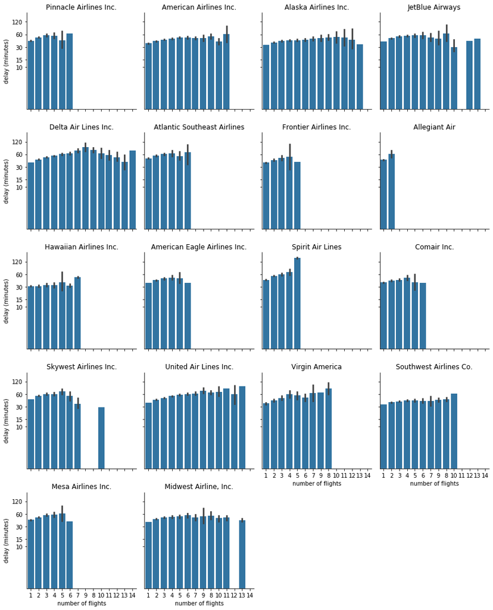

```python
flights = delayed_arrivals['FLIGHTS'].unique()
g = sb.FacetGrid(data=delayed_arrivals, col='OP_UNIQUE_CARRIER', col_wrap=4);
g.map(sb.barplot, 'FLIGHTS', 'ARR_DELAY_NORM', order=flights);
g.set_axis_labels('number of flights', 'delay (minutes)')
g.set(yticks=log_ticks);
g.set_yticklabels(delay_ticks);
for ax, title in zip(g.axes.flat, carriers.values()):
    ax.set_title(title)
```

> Each carrier does seem to have an optimum number of flights. JetBlue, for example, has the shortest delays when they operate around 10 flights. While Delta has the longest delays when they operate around 8 flights.

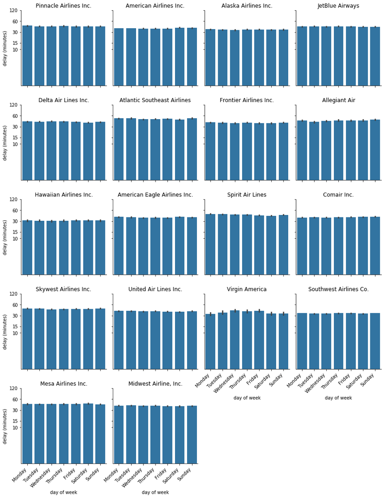

```python
g = sb.FacetGrid(data=delayed_arrivals, col='OP_UNIQUE_CARRIER', col_wrap=4);
g.map(sb.barplot, 'DAY_OF_WEEK', 'ARR_DELAY_NORM', order=[1,2,3,4,5,6,7]);
g.set_axis_labels('day of week', 'delay (minutes)')
g.set(yticks=log_ticks);
g.set_yticklabels(delay_ticks);
g.set_xticklabels(['Monday','Tuesday','Wednesday','Thursday','Friday','Saturday','Sunday'], rotation=45, horizontalalignment='right');
for ax, title in zip(g.axes.flat, carriers.values()):
    ax.set_title(title)
```

> The day of the week doesn't seem to matter for most carriers. Only a couple of carriers had even a slight change in delay times. One of those was Virgin America which experiences longer delays on Wednesday, Thursday and Friday. Spirit had slightly shorter delays on Friday and Saturday while American shows a slight uptick in delay times on Saturday and Sunday.

### Talk about some of the relationships you observed in this part of the investigation. Were there features that strengthened each other in terms of looking at your feature(s) of interest?

> The strongest relationship with delays seems to be the number of flights operated in a day followed by carrier. The month has some relationship as well. Distance varies quite a bit even for the same flight due to changes in flight patterns and thus probably isn't as good a predictor as number of flights.

### Were there any interesting or surprising interactions between features?

> I expected certain carriers to only operate one or a handful of flights per day but American doesn't operate any that make more than eleven trips in a day while Delta operates flights up to fourteen trips per day. Even though Saturday shows the lowest number of delayed flights the delay times did not vary significantly by day of week. Even though there were fewer delayed flights on Saturday making it a predictor for having a delay, it would not be a good predictor for the length of delay.